# DBH Growth Model for the Northern Forest

# Conclusion

Based on the above analysis, and earlier analyses, I propose the following covariates be incorporated into a “robust” dbh growth model: species, dbh, crown ratio, basal area, species specific basal area, overtopping basal area, species richness, dbh variability, forest type, landscape setting, site class, latitude, and longitude. Site class is included despite its low importance because it’s easy to incorporate, so it doesn’t really cost anything. Height and stocking are excluded despite being more important because they are hard to measure, and because using height drastically reduces the amount of data available for model training. Forest type and landscape setting are intermediate in that they represent a bit of extra effort (computational expense for forest type and inventory time for landscape setting) for a modest increase in accuracy.

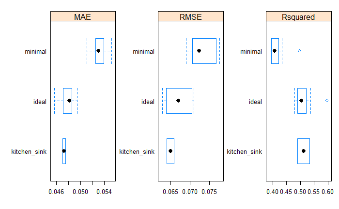

```r
train_minimal <- train %>%
  select(dbh_rate, spp, dbh, cr, ba, bal)

train_ideal <- train %>%
  select(dbh_rate, spp, dbh, cr, ba, bal, ba_ash:ba_yellow.birch, spp_rich,
         dbh_var, forest_type, landscape, site_class, lat, lon)

# Recipes
dbh_recipe23 <- recipe(dbh_rate ~ ., data = train_minimal) %>%
  step_dummy(all_nominal(), -all_outcomes()) %>%
  step_YeoJohnson(all_numeric(), -all_outcomes()) %>%
  step_center(all_numeric(), -all_outcomes()) %>%
  step_scale(all_numeric(), -all_outcomes()) %>%
  step_zv(all_predictors()) %>% # to remove any dummies with no occurrence
  step_corr(all_predictors(), threshold = 0.95) # Pearson's corr is default

dbh_recipe24 <- recipe(dbh_rate ~ ., data = train_ideal) %>%
  step_dummy(all_nominal(), -all_outcomes()) %>%
  step_YeoJohnson(all_numeric(), -all_outcomes()) %>%
  step_center(all_numeric(), -all_outcomes()) %>%
  step_scale(all_numeric(), -all_outcomes()) %>%
  step_zv(all_predictors()) %>% # to remove any dummies with no occurrence
  step_corr(all_predictors(), threshold = 0.95) # Pearson's corr is default

dbh_recipe25 <- recipe(dbh_rate ~ ., data = train) %>%
  step_dummy(all_nominal(), -all_outcomes()) %>%
  step_YeoJohnson(all_numeric(), -all_outcomes()) %>%
  step_center(all_numeric(), -all_outcomes()) %>%
  step_scale(all_numeric(), -all_outcomes()) %>%
  step_zv(all_predictors()) %>% # to remove any dummies with no occurrence
  step_corr(all_predictors(), threshold = 0.95) # Pearson's corr is default

# Train w/ RF
invisible({capture.output({
  # train in parallel to speed
  library(doParallel)
  cl <- makePSOCKcluster(10)
  registerDoParallel(cl)

  set.seed(seed)
  fit.minimal <- train(dbh_recipe23, train_minimal, method = 'ranger',
                     metric=metric, trControl=control)
  set.seed(seed)
  fit.ideal <- train(dbh_recipe24, train_ideal, method = 'ranger',
                   metric=metric, trControl=control)
  set.seed(seed)
  fit.ks <- train(dbh_recipe25, train, method = 'ranger',
                   metric=metric, trControl=control)

  stopCluster(cl)
})})

# Compare
results8 <- resamples(list(minimal = fit.minimal, ideal = fit.ideal,
                           kitchen_sink = fit.ks))
bwplot(results8, scales = scales)
```

At the least, this last comparison does nothing to invalidate the ‘ideal’ covariate list described above. Despite omitting many of the most computationally and practically expensive covariates, its accuracy is only negligibly lower than the expensive, ‘kitchen sink’ approach.